# HW6 Stats: Beta Binomial

Sophia Frantz

11/12/2019

# An overview of the data: bag of coins

This report describes the inferred probability distribution of the individual coin probabilities in a bag of coins. Each coin has its own probability of landing on heads. Peter has picked 100 coins from this bag and has flipped each coin a variable number of times and recorded how many times the coin landed on heads The histogram below shows the proportion of times each coin landed heads (calculated as number of heads divided by the total number of flips for each coin).

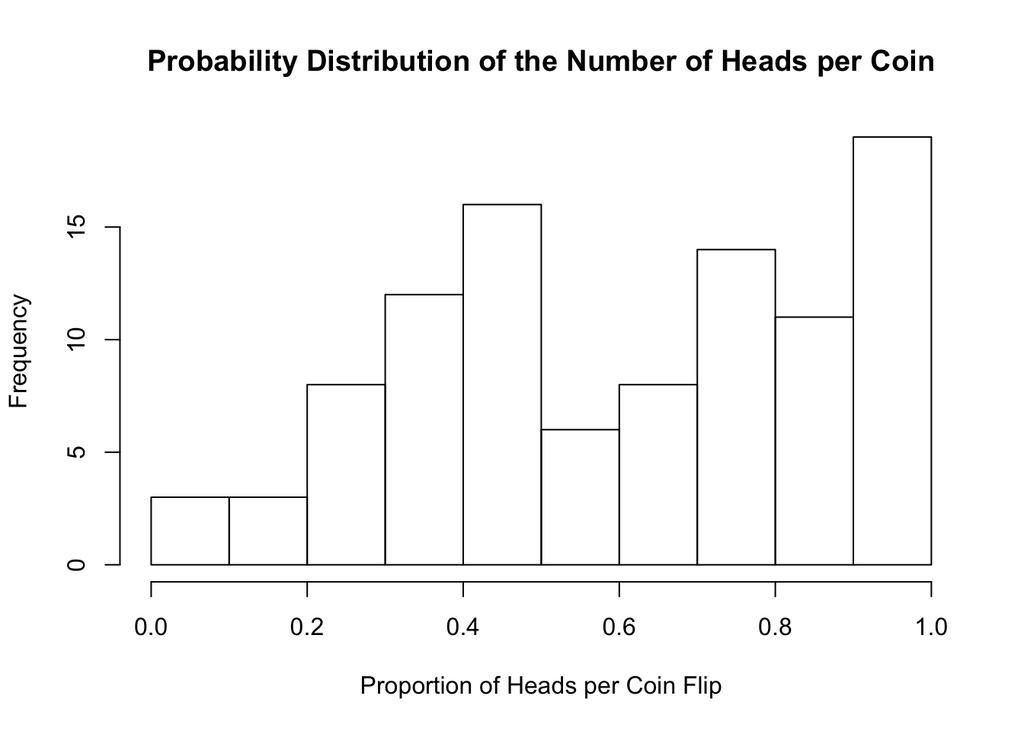

```
##    Min. 1st Qu.  Median    Mean 3rd Qu.    Max.
##  0.0000  0.4000  0.6307  0.6217  0.8365  1.0000
```

# Optimization: finding the appropriate alpha and beta to describe the data

We want to find the right parameters of the beta distribution to describe the distribution of probabilities of the bag of coins.

I created random different combinations of alpha and beta to try out. Both alpha and beta were sampled from a range of 1 to 10, with steps of 0.2. I sampled from this distribution 10,000 times for alpha and beta. I then made random combinations from this sample of alphas and betas. Using these different alphas and betas, I calculated the log likelihood for each coin in the trial. I used the beta binomial probability mass function to calculate this likelihood. I then calculated the sum of log likelihoods across all coins for each combination of alpha and beta. This results in a log likelihood of the entire trial of coin flips for different combinations of alphas and betas. Below is an example of the type of information the described calculations generated. It shows the values of alpha and beta, and the resulting sum of log likelihoods after applying the probability mass function.

```r
head(findMax)
```

```
##   alphas betas      sums
## 1    1.8   8.6 -426.6890
## 2    3.8  10.0 -346.6593
## 3    1.4   7.6 -433.6186
## 4    3.0   8.2 -340.2542
## 5    6.4   9.2 -265.0394
## 6    7.2   1.6 -244.3871
```

# Contour plot

After creating this data, I needed to determine which values of alpha and beta best describe the data. The combination of alpha and beta that results in the highest value of log likelihood is the most approproate parameter. To visualize the effects of alphas and betas on the likelihood, I created a contour plot, which plots a landscape of likelihoods for each alpha and beta. The contour plot is shown below.

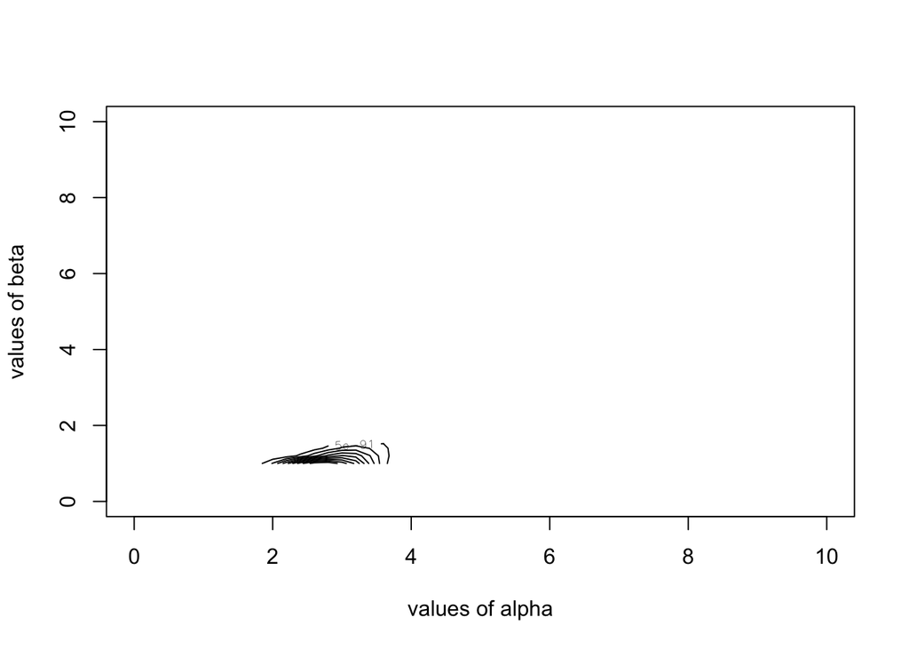

We can see the largest likelihoods are concentrated in one space. I maginfied this space in another plot below for a better look.

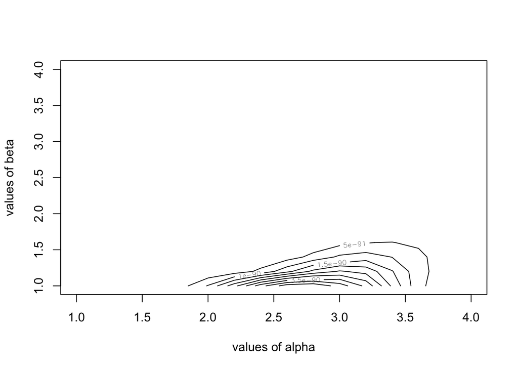

```r
max(newMatrix) #find the maximum sum of likelihoods, then find in the matrix the beta and alpha associated with it.
```

```
## [1] 4.907208e-90
```

# Beta Distribution

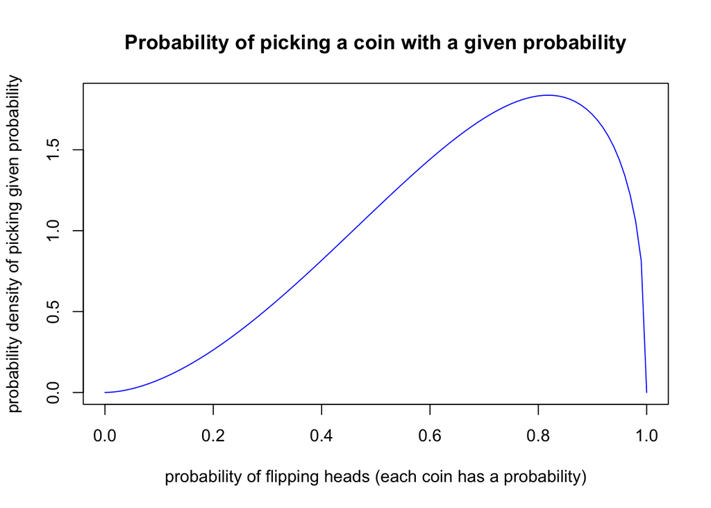